# BOO 2025 - Example Analysis

Script 5: Differential expression - Questions

Bärbel Smit

2025-05-22

> In this script, you will identify differentially expressed genes (DEGs) and visualize your results.

# 1 Setup

## 1.1 Clean

As before, we perform several setup steps at the start of the script to ensure our work is reproducible and clear.

**Exercise 1: Download the R markdown template, clean your environment, and set the following variables:**

- `root_dir` - project folder
- `count_path` - location of the `countData` object
- `metadata_path` - location of the `metaData` object
- `low_store` - location to store DEG results for the low toxicity compound
- `high_store` - location to store DEG results for the high toxicity compound

```r
# clean environment
rm(list=ls())
```

```r
# set variable
root_dir <- "C:/Users/Bärbel Smit/Universiteit Leiden/BOO 2025 - BOO CDS Giulia team - BOO CDS Giulia team/Students/Bärbel/project/barbelsmit_BOO/"
metadata_path <- file.path(root_dir, "output", "metaData_04_PCA.RData")
cpm_path <- file.path(root_dir, "output", "cpmData_04_PCA.RData")
count_path <- file.path(root_dir, "output", "countData_03samp_QC.RData")

low_store <- "DEG/DEGres_low.Rdata"
high_store <- "DEG/DEGres_high.Rdata"
```

## 1.2 Packages

In this script, we introduce a new package: `DESeq2`, a package that analyses count-based sequencing data, such as TempO-Seq, to identify differentially expressed genes between experimental conditions.

**Exercise 2: Load `DESeq2`, `ggrepel`, and `tidyverse` into your R environment:**

```r
#load packages
library(tidyverse)
library(ggrepel)
library(DESeq2)
```

## 1.3 Load data

**Exercise 3: Load the count and metadata into your R environment:**

```r
# loading data
load(count_path)
load(metadata_path)
```

# 2 DEG Analysis

## 2.1 Mean ID

In order to perform DEG analysis we need to ensure we have the correct `mean_ID` and `mean_ID_control` variables. These can be used to tell DESeq2 which samples to compare:

- `mean_ID` is a group identifier, describing which treatment condition each sample belongs to
- `mean_ID_control` is a control identifier, describing which control samples a group should be compared to

In the case of our data we will have:

- A `mean_ID` level for each experimental condition (7 concentrations for 2 compounds plus two plate-specific DMSO groups)
- No `mean_ID_control` for the DMSO controls, but the appropriate DMSO control specified for the treated samples

**Exercise 4: Identify these variables in your `metaData`:**

```r
metaData %>%
  # Select the columns mean ID and mean ID control
  select(mean_ID, mean_ID_control) %>%
  # Filter out the rows where mean ID control gives NA
  filter(!is.na(mean_ID_control)) %>%
  # Remove duplicate rows
  distinct()
```

|  | mean_ID | mean_ID_control |
| --- | --- | --- |
| CS1107_C1_P2_R1 | CS1107_1_P2 | DMSOLow_P2 |
| CS1107_C2_P2_R1 | CS1107_2_P2 | DMSOLow_P2 |
| CS1107_C3_P2_R1 | CS1107_3_P2 | DMSOLow_P2 |
| CS1107_C4_P2_R1 | CS1107_4_P2 | DMSOLow_P2 |
| CS1107_C5_P2_R1 | CS1107_5_P2 | DMSOLow_P2 |
| CS1107_C6_P2_R1 | CS1107_6_P2 | DMSOLow_P2 |
| CS1107_C7_P2_R1 | CS1107_7_P2 | DMSOHigh_P2 |
| CS1130_C1_P7_R1 | CS1130_1_P7 | DMSOLow_P7 |
| CS1130_C2_P7_R1 | CS1130_2_P7 | DMSOLow_P7 |
| CS1130_C3_P7_R1 | CS1130_3_P7 | DMSOLow_P7 |

[output cut: 4 more lines]

## 2.2 Contrast

DESeq2 uses an object called a contrast, which details the comparisons that will be run. We often want to save several comparisons together in one object, such as all results for each compound together.

**Exercise 5: Create a `contrast` data frame, including a variable `file_ID` which describes which file each comparison should be saved in:**

```r
contrast <- metaData %>%
  # Keep only rows where a control is defined
  filter(!is.na(mean_ID_control)) %>%
  # Select treatment and corresponding control group and also keep compound_ID, renamed to file_ID
  select(mean_ID, mean_ID_control, file_ID = compound_ID) %>%
  # Remove duplicate rows
  distinct

# Show contrast
contrast
```

|  | mean_ID | mean_ID_control | file_ID |
| --- | --- | --- | --- |
| CS1107_C1_P2_R1 | CS1107_1_P2 | DMSOLow_P2 | CS1107 |
| CS1107_C2_P2_R1 | CS1107_2_P2 | DMSOLow_P2 | CS1107 |
| CS1107_C3_P2_R1 | CS1107_3_P2 | DMSOLow_P2 | CS1107 |
| CS1107_C4_P2_R1 | CS1107_4_P2 | DMSOLow_P2 | CS1107 |
| CS1107_C5_P2_R1 | CS1107_5_P2 | DMSOLow_P2 | CS1107 |
| CS1107_C6_P2_R1 | CS1107_6_P2 | DMSOLow_P2 | CS1107 |
| CS1107_C7_P2_R1 | CS1107_7_P2 | DMSOHigh_P2 | CS1107 |
| CS1130_C1_P7_R1 | CS1130_1_P7 | DMSOLow_P7 | CS1130 |
| CS1130_C2_P7_R1 | CS1130_2_P7 | DMSOLow_P7 | CS1130 |
| CS1130_C3_P7_R1 | CS1130_3_P7 | DMSOLow_P7 | CS1130 |

[output cut: 4 more lines]

## 2.3 Subsets

We want to perform DEG analysis for each concentration of the low and high toxicity compounds.

**Exercise 6: Subset `contrast` to include only the comparisons for the low toxicity compound and create a vector `levels` which can be used to loop through the selected `mean_ID`:**

```r
contrast_low <- contrast %>%
  # Keep only rows where the compound is CS1107
  filter(file_ID == "CS1107")

# Show output contrast low tox
contrast_low
```

|  | mean_ID | mean_ID_control | file_ID |
| --- | --- | --- | --- |
| CS1107_C1_P2_R1 | CS1107_1_P2 | DMSOLow_P2 | CS1107 |
| CS1107_C2_P2_R1 | CS1107_2_P2 | DMSOLow_P2 | CS1107 |
| CS1107_C3_P2_R1 | CS1107_3_P2 | DMSOLow_P2 | CS1107 |
| CS1107_C4_P2_R1 | CS1107_4_P2 | DMSOLow_P2 | CS1107 |
| CS1107_C5_P2_R1 | CS1107_5_P2 | DMSOLow_P2 | CS1107 |
| CS1107_C6_P2_R1 | CS1107_6_P2 | DMSOLow_P2 | CS1107 |
| CS1107_C7_P2_R1 | CS1107_7_P2 | DMSOHigh_P2 | CS1107 |

```r
# Show all the unique treatment groups (mean_IDs) associated with the compound "CS1107" from contrast_low data frame
levels <- unique(contrast_low$mean_ID)

levels
```

```
## [1] "CS1107_1_P2" "CS1107_2_P2" "CS1107_3_P2" "CS1107_4_P2" "CS1107_5_P2"
## [6] "CS1107_6_P2" "CS1107_7_P2"
```

Before looping through `levels`, let’s go through the steps required to perform a DEG analysis.

**Exercise 7: Using the first value in `levels`, subset the `contrast`, `countData`, and `metaData` to include only the relevant samples:**

**Hint**

Make sure you create new objects, such as `countData_sub` and `metaData_sub` to prevent overwriting the full data frame.

```r
# Set i to the first treatment group from the levels vector
i <- levels[1]
i
```

```
## [1] "CS1107_1_P2"
```

```r
# Filter contrast_low to extract the row corresponding to the first treatment group (i) for the compound CS1107
contrast_sub <- contrast_low %>%
  filter(mean_ID == i)
contrast_sub
```

|  | mean_ID | mean_ID_control | file_ID |
| --- | --- | --- | --- |
| CS1107_C1_P2_R1 | CS1107_1_P2 | DMSOLow_P2 | CS1107 |

```r
# Filter metaData to create metaData_sub, containing only the samples that belong to either the treatment group (mean_ID) or its corresponding control group (mean_ID_control) specified in contrast_sub
metaData_sub <- metaData %>%
  filter(mean_ID %in% c(contrast_sub$mean_ID, contrast_sub$mean_ID_control))
metaData_sub
```

|  | sample_ID | sample_type | compound_ID | compound_CAS | compound_name | compound_abbr | mean_ID | mean_ID_control | control_type | conc_ID | conc_amt | conc_unit | conc_max | conc_min | rep | lib_size | read_depth | plate_ID | plate_well | plate_row | plate_col | batch | timepoint | cell_type | compound_class | LOAEL_amt | LOAEL_unit | PBPK_equivalent | PBPK_serum_level | … |
| --- | --- | --- | --- | --- | --- | --- | --- | --- | --- | --- | --- | --- | --- | --- | --- | --- | --- | --- | --- | --- | --- | --- | --- | --- | --- | --- | --- | --- | --- | --- |
| CS1107_C1_P2_R1 | CS1107_C1_P2_R1 | Treatment | CS1107 | 1115-70-4 | Metformin | Metformin | CS1107_1_P2 | DMSOLow_P2 | DMSOLow | 1 | 0.03 | µM | 180 | 0.03 | 1 | 3543936 | 157.83336 | P2 | A3 | A | 3 | 1 | 24 | PHH | Low toxicity | 450 | mg/kg/d | 17.01245 | 10 mg/kg | … |
| CS1107_C1_P2_R2 | CS1107_C1_P2_R2 | Treatment | CS1107 | 1115-70-4 | Metformin | Metformin | CS1107_1_P2 | DMSOLow_P2 | DMSOLow | 1 | 0.03 | µM | 180 | 0.03 | 2 | 3900778 | 173.71136 | P2 | A3 | A | 3 | 1 | 24 | PHH | Low toxicity | 450 | mg/kg/d | 17.01245 | 10 mg/kg | … |
| CS1107_C1_P2_R3 | CS1107_C1_P2_R3 | Treatment | CS1107 | 1115-70-4 | Metformin | Metformin | CS1107_1_P2 | DMSOLow_P2 | DMSOLow | 1 | 0.03 | µM | 180 | 0.03 | 3 | 1803661 | 80.29872 | P2 | G1 | G | 1 | 1 | 24 | PHH | Low toxicity | 450 | mg/kg/d | 17.01245 | 10 mg/kg | … |
| DMSOLow1_C1_P2_R1 | DMSOLow1_C1_P2_R1 | Control | DMSOLow | NA | DMSO | DMSO | DMSOLow_P2 | NA | NA | 0 | NA | NA | NA | NA | 1 | 4238562 | 188.70492 | P2 | H2 | H | 2 | NA | 24 | PHH | NA | NA | NA | NA | NA | … |
| DMSOLow2_C1_P2_R1 | DMSOLow2_C1_P2_R1 | Control | DMSOLow | NA | DMSO | DMSO | DMSOLow_P2 | NA | NA | 0 | NA | NA | NA | NA | 1 | 3889689 | 173.16309 | P2 | H3 | H | 3 | NA | 24 | PHH | NA | NA | NA | NA | NA | … |
| DMSOLow1_C1_P2_R2 | DMSOLow1_C1_P2_R2 | Control | DMSOLow | NA | DMSO | DMSO | DMSOLow_P2 | NA | NA | 0 | NA | NA | NA | NA | 2 | 4495122 | 200.09524 | P2 | H2 | H | 2 | NA | 24 | PHH | NA | NA | NA | NA | NA | … |
| DMSOLow2_C1_P2_R2 | DMSOLow2_C1_P2_R2 | Control | DMSOLow | NA | DMSO | DMSO | DMSOLow_P2 | NA | NA | 0 | NA | NA | NA | NA | 2 | 4027511 | 179.29424 | P2 | H3 | H | 3 | NA | 24 | PHH | NA | NA | NA | NA | NA | … |
| DMSOLow1_C1_P2_R3 | DMSOLow1_C1_P2_R3 | Control | DMSOLow | NA | DMSO | DMSO | DMSOLow_P2 | NA | NA | 0 | NA | NA | NA | NA | 3 | 1758140 | 78.28256 | P2 | C2 | C | 2 | NA | 24 | PHH | NA | NA | NA | NA | NA | … |
| DMSOLow2_C1_P2_R3 | DMSOLow2_C1_P2_R3 | Control | DMSOLow | NA | DMSO | DMSO | DMSOLow_P2 | NA | NA | 0 | NA | NA | NA | NA | 3 | 1931175 | 85.96649 | P2 | D2 | D | 2 | NA | 24 | PHH | NA | NA | NA | NA | NA | … |

```r
# Subset the countData to include only the columns (samples) listed in metaData_sub$sample_ID, creating countData_sub, which contains count data only for the treatment and control samples relevant to the current contrast
countData_sub <- countData[ , metaData_sub$sample_ID]
countData_sub[1:10, ]
```

|  | CS1107_C1_P2_R1 | CS1107_C1_P2_R2 | CS1107_C1_P2_R3 | DMSOLow1_C1_P2_R1 | DMSOLow2_C1_P2_R1 | DMSOLow1_C1_P2_R2 | DMSOLow2_C1_P2_R2 | DMSOLow1_C1_P2_R3 | DMSOLow2_C1_P2_R3 |
| --- | --- | --- | --- | --- | --- | --- | --- | --- | --- |
| A1BG | 2220 | 2667 | 1316 | 2059 | 2097 | 2628 | 2356 | 1226 | 1290 |
| A1CF | 576 | 663 | 209 | 564 | 565 | 601 | 543 | 240 | 261 |
| A2M | 186 | 182 | 85 | 221 | 175 | 252 | 277 | 89 | 113 |
| A4GALT | 9 | 23 | 15 | 26 | 27 | 31 | 17 | 15 | 15 |
| AAAS | 18 | 19 | 15 | 46 | 37 | 25 | 16 | 18 | 13 |
| AACS | 87 | 92 | 44 | 99 | 109 | 112 | 124 | 63 | 45 |
| AADAC | 100 | 111 | 81 | 200 | 125 | 163 | 170 | 63 | 55 |
| AADAT | 7 | 9 | 4 | 17 | 21 | 5 | 8 | 4 | 8 |
| AAGAB | 755 | 725 | 342 | 931 | 724 | 914 | 845 | 325 | 425 |
| AAK1 | 85 | 107 | 41 | 77 | 125 | 103 | 86 | 27 | 47 |

## 2.4 Fit models

Now that we have subset our data, we can use it to create a DESeq object (`dds`). This also requires us to set our `design`, or model formula. In our data, this will be a simple comparison of two levels of `mean_ID`.

**Exercise 8: Use the `DESeqDataSetFromMatrix()` function to create a `dds` object:**

**Hint**

Designs are a special type of object in R, the formula, which is specified using a tilde (e.g. `~ mean_ID`).

```r
# Create a DESeq2 dataset object
dds <- DESeqDataSetFromMatrix(
  countData = countData_sub,
  colData = metaData_sub,
# Specify that gene expression differences will be tested based on the treatment group (mean_ID)
  design = ~ mean_ID
)
```

Next, we use the `DESeq()` function to:

1. Calculate **size factors** using the median ratio method, which normalizes for differences in sequencing depth or library size across samples. The motivation is similar to CPM normalization, but each sample is instead compared to a pseudo-reference sample composed of the geometric mean of all genes.
2. Estimate **dispersions** (biological variability) for each gene across replicates, in order to properly quantify confidence in results (which will be lower for highly variable genes).
3. Fit a **generalized linear model** (GLM) for each gene, using a negative Binomial distribution. This takes the normalized counts (from size factors), design formula, and estimated dispersion to produce log2 fold changes (log2FC), standard errors (SEs), and p-values.

The output object, `dds`, contains all the model fits and is ready for extracting results.

**Exercise 9: Use the `DESeq()` function to update the `dds` object and include all specified model fits:**

```r
# Run DESeq2 analysis on dataset dds
dds <- DESeq(dds)
dds
```

```
## class: DESeqDataSet
## dim: 13101 9
## metadata(1): version
## assays(4): counts mu H cooks
## rownames(13101): A1BG A1CF ... ZZEF1 ZZZ3
## rowData names(22): baseMean baseVar ... deviance maxCooks
## colnames(9): CS1107_C1_P2_R1 CS1107_C1_P2_R2 ... DMSOLow1_C1_P2_R3
##   DMSOLow2_C1_P2_R3
## colData names(43): sample_ID sample_type ... high_PC1 sizeFactor
```

## 2.5 Extract results

Results can be extracted from a `dds` object using the `results()` function. However, we additionally apply shrinkage to our results. **Shrinkage** pulls extreme or noisy log2FC towards zero when they are not well supported by the data, usually due to:

- Low expression levels
- High dispersion (biological variability)
- Small sample sizes

Shrunk log2FC are more stable and realistic, especially in these scenarios. **Normal** shrinkage uses a Normal prior distribution (bell curve with its peak at 0), which assumes that most genes are not differentially expressed and encourages smaller fold changes unless there is strong evidence to the contrary.

The final log2FCs are then a posterior estimate that combines:

- The observed data, and
- The prior (Normal distribution centered at 0)

**Exercise 10: Use `lfcShrink()` to extract results for the selected comparison:**

**Hint**

You will get a warning using normal shrinkage, but our experience suggests that it is the best method for these simpler designs.

```r
# Shrink the estimated fold changes between the treatment (contrast_sub$mean_ID) and its control (contrast_sub$mean_ID_control) to produce more stable and reliable estimates, in particular for genes with low counts or high variability
res_low <- lfcShrink(dds,
                 contrast = c("mean_ID",
                              contrast_sub$mean_ID,
                              contrast_sub$mean_ID_control),
                 type="normal")
```

```
## using 'normal' for LFC shrinkage, the Normal prior from Love et al (2014).
##
## Note that type='apeglm' and type='ashr' have shown to have less bias than type='normal'.
## See ?lfcShrink for more details on shrinkage type, and the DESeq2 vignette.
## Reference: https://doi.org/10.1093/bioinformatics/bty895
```

```r
# Display the first rows of the shrunken differential expression results, showing key information(log2 fold change, standard errors, statistical test statistics, p_values ans adjusted p-values)
head(res_low)
```

```
## log2 fold change (MAP): mean_ID CS1107_1_P2 vs DMSOLow_P2
## Wald test p-value: mean_ID CS1107_1_P2 vs DMSOLow_P2
## DataFrame with 6 rows and 6 columns
##         baseMean log2FoldChange     lfcSE      stat    pvalue      padj
##        <numeric>      <numeric> <numeric> <numeric> <numeric> <numeric>
## A1BG   1900.7718       0.173747  0.101253  1.716036 0.0861555  0.298661
## A1CF    429.2251       0.126426  0.102302  1.235402 0.2166811  0.492755
## A2M     161.9073      -0.156105  0.132042 -1.181569 0.2373767  0.515609
## A4GALT   19.4675      -0.130215  0.176680 -0.749693 0.4534399        NA
## AAAS     22.0893      -0.172778  0.177365 -0.988811 0.3227558        NA
## AACS     80.9969      -0.147778  0.152140 -0.971266 0.3314160  0.606773
```

- `baseMean`: The average normalized expression level of a gene across all samples, showing how much the gene is expressed overall
- `log2FoldChange`: The log base 2 of the fold change in expression between two groups (treatment vs. control). Positive means higher in treatment, negative means lower
- `lfcSE`: The standard error of the log2 fold change estimate, indicating how precise the fold change measurement is (uncertainty)
- `stat`: The test statistic value used to assess whether the log2 fold change is significantly different from zero
- `pvalue`: The probability of observing the data if there were actually no difference between groups, smaller values suggest stronger evidence against no change
- `padj`: The p-value adjusted for multiple testing, controlling the false discovery rate to reduce false positives when testing many genes

**Exercise 11: Wrangle the output to additional columns:**

- `gene_symbol` containing the gene names
- `mean_ID` containing the mean ID of the treated samples
- `mean_ID_control` containing the mean ID of the control samples

```r
# Convert DESeq2 results res_low into a data frame
res_low <- data.frame(res_low) %>%
# Move the gene names from row names into a new column called "gene_symbol"
  rownames_to_column(var = "gene_symbol") %>%
# Add the mean_ID and mean_ID_control columns to label the treatment and control groups
  mutate(
    mean_ID = contrast_sub$mean_ID,
    mean_ID_control = contrast_sub$mean_ID_control
  )
# Show first rows
head(res_low)
```

|  | gene_symbol | baseMean | log2FoldChange | lfcSE | stat | pvalue | padj | mean_ID | mean_ID_control |
| --- | --- | --- | --- | --- | --- | --- | --- | --- | --- |
| 1 | A1BG | 1900.77185 | 0.1737469 | 0.1012532 | 1.7160357 | 0.08615551 | 0.2986615 | CS1107_1_P2 | DMSOLow_P2 |
| 2 | A1CF | 429.22507 | 0.1264255 | 0.1023018 | 1.2354016 | 0.21668108 | 0.4927550 | CS1107_1_P2 | DMSOLow_P2 |
| 3 | A2M | 161.90735 | -0.1561048 | 0.1320422 | -1.1815693 | 0.23737666 | 0.5156092 | CS1107_1_P2 | DMSOLow_P2 |
| 4 | A4GALT | 19.46755 | -0.1302149 | 0.1766797 | -0.7496926 | 0.45343985 | NA | CS1107_1_P2 | DMSOLow_P2 |
| 5 | AAAS | 22.08929 | -0.1727781 | 0.1773654 | -0.9888107 | 0.32275575 | NA | CS1107_1_P2 | DMSOLow_P2 |
| 6 | AACS | 80.99690 | -0.1477776 | 0.1521404 | -0.9712656 | 0.33141602 | 0.6067733 | CS1107_1_P2 | DMSOLow_P2 |

## 2.6 Loop

Using a `for` loop, you can run each of these steps for every required comparison.

**Exercise 12: Loop through the remaining values of the `levels` variable to add all of the comparisons for the low toxicity compound to your `res` object:**

```r
# Select the current treatment-control pair from contrast_low
for(i in levels[-1]){
  contrast_sub <- contrast_low %>%
    filter(mean_ID == i)
  # Keep samples only from this treatment and its control group
  metaData_sub <- metaData %>%
    filter(mean_ID %in% c(contrast_sub$mean_ID, contrast_sub$mean_ID_control))
  # Filter countData to include only the relevant samples
  countData_sub <- countData[ , metaData_sub$sample_ID]
# Build a DESeqDataSet object with the subsetted counts and metadata
  dds <- DESeqDataSetFromMatrix(
    countData = countData_sub,
    colData = metaData_sub,
    design = ~ mean_ID)
  # Run DESeq
  dds <- DESeq(dds)
  # Get stable fold changes, by shrinking, for the treatment vs control. Convert results to a data frame, add gene symbols and group info. Combine results in res_low
  res_low <- rbind(res_low,
    data.frame(lfcShrink(dds,
                 contrast = c("mean_ID",
                              contrast_sub$mean_ID,
                              contrast_sub$mean_ID_control),
                 type="normal")) %>%
    rownames_to_column(var = "gene_symbol") %>%
    mutate(
      mean_ID = contrast_sub$mean_ID,
      mean_ID_control = contrast_sub$mean_ID_control))
}
```

[output not shown]

[output not shown]

[output not shown]

[output not shown]

[output not shown]

[output not shown]

```r
# Show first rows
head(res_low)
```

|  | gene_symbol | baseMean | log2FoldChange | lfcSE | stat | pvalue | padj | mean_ID | mean_ID_control |
| --- | --- | --- | --- | --- | --- | --- | --- | --- | --- |
| 1 | A1BG | 1900.77185 | 0.1737469 | 0.1012532 | 1.7160357 | 0.08615551 | 0.2986615 | CS1107_1_P2 | DMSOLow_P2 |
| 2 | A1CF | 429.22507 | 0.1264255 | 0.1023018 | 1.2354016 | 0.21668108 | 0.4927550 | CS1107_1_P2 | DMSOLow_P2 |
| 3 | A2M | 161.90735 | -0.1561048 | 0.1320422 | -1.1815693 | 0.23737666 | 0.5156092 | CS1107_1_P2 | DMSOLow_P2 |
| 4 | A4GALT | 19.46755 | -0.1302149 | 0.1766797 | -0.7496926 | 0.45343985 | NA | CS1107_1_P2 | DMSOLow_P2 |
| 5 | AAAS | 22.08929 | -0.1727781 | 0.1773654 | -0.9888107 | 0.32275575 | NA | CS1107_1_P2 | DMSOLow_P2 |
| 6 | AACS | 80.99690 | -0.1477776 | 0.1521404 | -0.9712656 | 0.33141602 | 0.6067733 | CS1107_1_P2 | DMSOLow_P2 |

```r
# Show dimensions of res_low
dim(res_low)
```

```
## [1] 91707     9
```

rows: Each row represents a gene in one treatment-vs-control comparison columns: Includes the columns gene_symbol, baseMean, log2FoldChange, lfcSE, stat, pvalue, padj, plus the added mean_ID and mean_ID_control

**Exercise 13: Perform DEG analysis for the high toxicity compound, saving the output in `res_high`:**

First, we make the contrast for the high toxicity compound and save the levels:

```r
# Keep only rows where the compound is CS1130
contrast_high <- contrast %>%
  filter(file_ID == "CS1130")
# Show output contrast high tox
contrast_high
```

|  | mean_ID | mean_ID_control | file_ID |
| --- | --- | --- | --- |
| CS1130_C1_P7_R1 | CS1130_1_P7 | DMSOLow_P7 | CS1130 |
| CS1130_C2_P7_R1 | CS1130_2_P7 | DMSOLow_P7 | CS1130 |
| CS1130_C3_P7_R1 | CS1130_3_P7 | DMSOLow_P7 | CS1130 |
| CS1130_C4_P7_R1 | CS1130_4_P7 | DMSOLow_P7 | CS1130 |
| CS1130_C5_P7_R1 | CS1130_5_P7 | DMSOLow_P7 | CS1130 |
| CS1130_C6_P7_R1 | CS1130_6_P7 | DMSOLow_P7 | CS1130 |
| CS1130_C7_P7_R1 | CS1130_7_P7 | DMSOHigh_P7 | CS1130 |

```r
# Show all the unique treatment groups (mean_IDs) associated with the compound "CS1130" from your contrast_high data frame
levels <- unique(contrast_high$mean_ID)

levels
```

```
## [1] "CS1130_1_P7" "CS1130_2_P7" "CS1130_3_P7" "CS1130_4_P7" "CS1130_5_P7"
## [6] "CS1130_6_P7" "CS1130_7_P7"
```

Then, we loop through `levels` and save results:

```r
res_high <- data.frame()
# Select the current treatment-control pair from contrast_high
for(i in levels){
  contrast_sub <- contrast_high %>%
    filter(mean_ID == i)
  # Keep samples only from this treatment and its control group
  metaData_sub <- metaData %>%
    filter(mean_ID %in% c(contrast_sub$mean_ID, contrast_sub$mean_ID_control))
  # Filter countData to include only the relevant samples
  countData_sub <- countData[ , metaData_sub$sample_ID]
# Build a DESeqDataSet object with the subsetted counts and metadata
  dds <- DESeqDataSetFromMatrix(
    countData = countData_sub,
    colData = metaData_sub,
    design = ~ mean_ID)
  # Run DESeq
  dds <- DESeq(dds)
  # Get stable fold changes, by shrinking, for the treatment vs control. Convert results to a data frame, add gene symbols and group info. Combine results in res_high
  res_high <- rbind(res_high,
    data.frame(lfcShrink(dds,
                 contrast = c("mean_ID",
                              contrast_sub$mean_ID,
                              contrast_sub$mean_ID_control),
                 type="normal")) %>%
    rownames_to_column(var = "gene_symbol") %>%
    mutate(
      mean_ID = contrast_sub$mean_ID,
      mean_ID_control = contrast_sub$mean_ID_control))
}
```

[output not shown]

[output not shown]

[output not shown]

[output not shown]

[output not shown]

[output not shown]

[output not shown]

```r
# Show first rows
head(res_high)
```

|  | gene_symbol | baseMean | log2FoldChange | lfcSE | stat | pvalue | padj | mean_ID | mean_ID_control |
| --- | --- | --- | --- | --- | --- | --- | --- | --- | --- |
| 1 | A1BG | 2007.26713 | 0.15951857 | 0.07904113 | 2.0178612 | 0.04360572 | 0.2572099 | CS1130_1_P7 | DMSOLow_P7 |
| 2 | A1CF | 431.79105 | -0.02129440 | 0.08870563 | -0.2400367 | 0.81030184 | 0.9305535 | CS1130_1_P7 | DMSOLow_P7 |
| 3 | A2M | 213.11656 | 0.02038208 | 0.13396092 | 0.1519360 | 0.87923742 | 0.9591412 | CS1130_1_P7 | DMSOLow_P7 |
| 4 | A4GALT | 20.19147 | -0.05047750 | 0.14001951 | -0.3624683 | 0.71700212 | NA | CS1130_1_P7 | DMSOLow_P7 |
| 5 | AAAS | 24.27481 | -0.25505199 | 0.14133951 | -1.8347405 | 0.06654415 | NA | CS1130_1_P7 | DMSOLow_P7 |
| 6 | AACS | 90.59131 | 0.08909339 | 0.12649546 | 0.7050058 | 0.48080662 | 0.7638697 | CS1130_1_P7 | DMSOLow_P7 |

```r
# Show dimensions of res_high
dim(res_high)
```

```
## [1] 91707     9
```

# 3 Defining DEGs

## 3.1 Thresholds

There are many ways to define a differentially expressed gene based either on the log2 fold change (log2FC, which reflects the effect size), the adjusted p-value (which reflects the statistical significance after correcting for multiple testing), or a combination of both. For example, some studies may define a gene as differentially expressed if it has an adjusted p-value below 0.05, indicating high statistical confidence, while others may require an absolute log2FC above log2(1.2) (i.e., a twenty percent change) to ensure the change is also biologically meaningful. Combining both criteria helps balance sensitivity and specificity, reducing the chance of identifying genes that are statistically but not biologically relevant, or vice versa.

**Exercise 14: Create two new variables `dir` and `sig` that describe each gene’s significance (T/F) and direction of effect (up/down):**

**Hint**

Don’t forget to do it for the high and low toxicity compounds.

```r
# Add new columns dir en sig to res_high
res_high <- res_high %>%
  mutate(
# Up when lo2FC is positive and Down when its negative
    dir = ifelse(log2FoldChange < 0, "Down", "Up"),
# Flags whether a gene is significantly differentially expressed based on: padj <= 0.05 and FC greater than 20% (TRUE). FALSE is otherwise
    sig = ifelse(padj <= 0.05 & abs(log2FoldChange) > log2(1.2), TRUE, FALSE)
  )

table(res_high$sig, res_high$dir, useNA="always")
```

```
##
##          Down    Up  <NA>
##   FALSE 44753 44543     0
##   TRUE    220   284     0
##   <NA>    819   880   208
```

```r
# Add new columns dir en sig to res_low
res_low <- res_low %>%
  mutate(
# Up when lo2FC is positive and Down when its negative
    dir = ifelse(log2FoldChange < 0, "Down", "Up"),
# Flags whether a gene is significantly differentially expressed based on: padj <= 0.05 and FC greater than 20% (TRUE). FALSE is otherwise
    sig = ifelse(padj <= 0.05 & abs(log2FoldChange) > log2(1.2), TRUE, FALSE)
  )

table(res_low$sig, res_low$dir, useNA="always")
```

```
##
##          Down    Up  <NA>
##   FALSE 44540 42496     0
##   TRUE   1811  1755     0
##   <NA>    490   483   132
```

When comparing the significantly expressed genes (marked as TRUE) between the low and high resolution groups, the low resolution group shows a notably larger number of genes passing the significance threshold. In particular, there are only 504 differentially expressed genes (either up- or down-regulated) in the high resolution group, while there are up to 3,566 in the low resolution group.

## 3.2 Save

It is important to save output of analyses locally, especially when they can be quite lengthy to rerun. This will save you considerable time later in the project.

**Exercise 15: Save the results using the path variables you created at the start of the script:**

```r
# save results
save(res_low, file=paste0(root_dir, low_store))
save(res_high, file=paste0(root_dir, high_store))
```

# 4 Plots

## 4.1 Dose-response plots

One of the plots that is useful to make following DEG analysis is visualization of any dose response effects. In order to ensure that all data point are plotted correctly, it is helpful to create a base data frame for all the direction, concentration combinations.

**Exercise 16: Create a data frame `plot_df` with all compound, concentration, and direction combinations:**

**Hint**

It may be helpful to `rbind()` your high and low toxicity compound results together for visualizations.

```r
# Combine res_high and res_low into a single data frame called res
res <- rbind(res_high, res_low)

plot_df <- res %>%
# Keep only rows where the dir column is not NA
  filter(!is.na(dir)) %>%
# Keeps only two columns: mean ID and dir
  select(mean_ID, dir) %>%
# Remove any duplicate rows
  distinct()
# The resulting plot_df is data frame containing only the gene IDs and their direction of differential expression
plot_df
```

| mean_ID | dir |
| --- | --- |
| CS1130_1_P7 | Up |
| CS1130_1_P7 | Down |
| CS1130_2_P7 | Up |
| CS1130_2_P7 | Down |
| CS1130_3_P7 | Up |
| CS1130_3_P7 | Down |
| CS1130_4_P7 | Up |
| CS1130_4_P7 | Down |
| CS1130_5_P7 | Up |
| CS1130_5_P7 | Down |

[output cut: 18 more lines]

Using `mean_ID` and `separate()`, you can extract information about the compound and concentration of each experimental group.

**Exercise 17: Create a data frame containing the number of DEGs, concentration, and compound, for each experimental condition and direction:**

**Hint**

Don’t forget to set the number of DEGs to 0, where appropriate.

```r
plot_df <- res %>%
  # Keep only rows where the result is statistically significant and the direction of change is defined
  filter(sig == TRUE & !is.na(dir)) %>%
  # Group data by mean ID and dir
  group_by(mean_ID, dir) %>%
  # Create a new column n that counts how many significant results exist for each unique combination of mean_ID and dir
  summarize(n = n(), .groups = "drop") %>%
  # Joins this summary with the original plot_df
  right_join(y = plot_df, by = c("mean_ID", "dir")) %>%
  # Replace any NA values in the count column with zeros
  mutate(n = ifelse(is.na(n), 0, n)) %>%
  # Split the mean_ID column
  separate(mean_ID, sep="_", into=c("Compound", "Conc_ID", NA), remove=F)

plot_df
```

| mean_ID | Compound | Conc_ID | dir | n |
| --- | --- | --- | --- | --- |
| CS1107_1_P2 | CS1107 | 1 | Down | 324 |
| CS1107_1_P2 | CS1107 | 1 | Up | 257 |
| CS1107_2_P2 | CS1107 | 2 | Down | 3 |
| CS1107_2_P2 | CS1107 | 2 | Up | 2 |
| CS1107_3_P2 | CS1107 | 3 | Up | 1 |
| CS1107_4_P2 | CS1107 | 4 | Down | 2 |
| CS1107_5_P2 | CS1107 | 5 | Down | 14 |
| CS1107_5_P2 | CS1107 | 5 | Up | 3 |
| CS1107_6_P2 | CS1107 | 6 | Up | 1 |
| CS1107_7_P2 | CS1107 | 7 | Down | 1468 |

[output cut: 18 more lines]

**Exercise 18: Plot the number of DEGs across concentrations for the two compounds. Do you see a dose-response?**

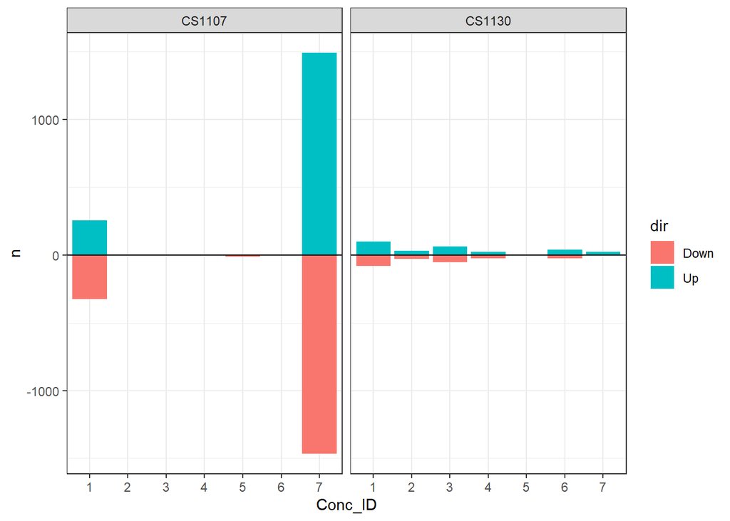

```r
#
plot_df %>%
  mutate(n = ifelse(dir == "Down", -n, n)) %>%
  ggplot(aes(x=Conc_ID, y=n, fill=dir)) +
  geom_col() +
  geom_hline(aes(yintercept=0)) +
  theme_bw() +
  facet_wrap(~Compound ,scales="free_x")
```

Analyzing Theophylline’s (CS1130) dose-response plot requires taking into account the drug’s pharmacodynamics and sample collection timing. Many of theophylline’s actions, including adenosine receptor antagonism and cAMP-PKA activation, happen quickly after delivery because it is a fast-acting drug. Therefore, at the 24-hour mark, early or transient gene expression responses—especially those involving immediate-early genes—may already have normalized. Likewise, drug-induced short-lived signaling events might have ended, therefore sampling at 24 hours might completely miss these acute molecular reactions.

Furthermore, looking at the mechanism of action (MoA), it does not directly interact with certain genes. Many of the effects of Theophylline involve post-transcriptional, post-translational, or signaling-based regulation, explaining why they are not captured in a standard DEG dataset. To draw meaningful conclusions on the impact of the drug, more analysis must be done at the systems level which integrates gene expression with pathways, protein activity, and cellular context.

## 4.2 Volcano plots

A volcano plot is useful to visualize effect sizes and significance of each gene in one plot, by plotting log2 fold changes (x-axis) against -log10 p-values (y-axis).

**Exercise 19: Create volcano plots for each of the compounds:**

**Hint**

If you want to plot all concentrations, it may be sensible to create distinct plots for the two compounds. However, you could also plot only the top concentration volcano plot, if the dose response is suggestive that this would be more informative.

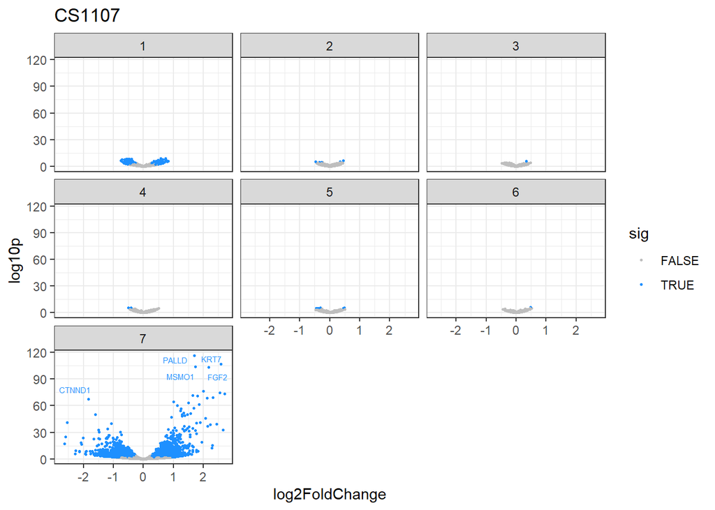

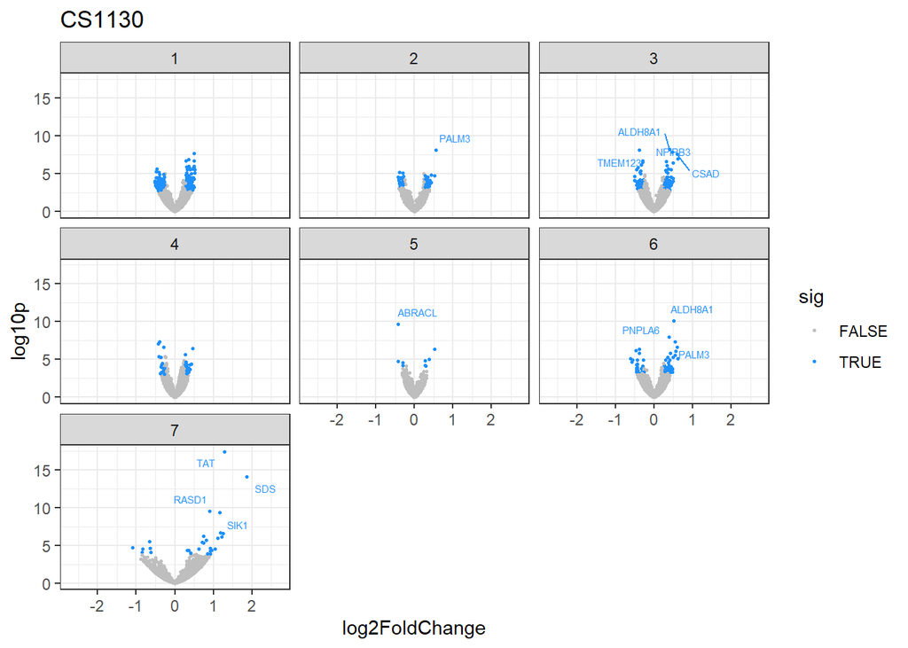

```r
#
for(i in unique(metaData$compound_ID)[1:2]) {
  print(res %>%
          separate(mean_ID, sep="_", into=c("Compound", "Conc_ID", NA), remove=F) %>%
          filter(!is.na(sig) & Compound == i) %>%
          mutate(log10p = -log10(pvalue)) %>%
          ggplot(aes(x = log2FoldChange, y = log10p)) +
          geom_point(aes(color=sig), size=0.5) +
          geom_text_repel(aes(label = ifelse(padj < 1E-4, gene_symbol, NA)),
                    color="dodgerblue", size=2) +
          xlim(-max(abs(res$log2FoldChange), na.rm=T), max(abs(res$log2FoldChange), na.rm=T)) +
          scale_color_manual(values = c("grey", "dodgerblue")) +
          theme_bw() +
          ggtitle(i) +
          facet_wrap(~Conc_ID))
}
```

CS1107 at highest concentration: - CTNND1: Linked to cell adhesion and epithelial integrity. - PALLD: Is involved in the modulation of the actin cytoskeleton - MSMO1: Enzyme involved in cholesterol biosynthesis. - KRT7: Helps maintain the structural integrity of epithelial cells, particularly simple epithelia lining internal organs, glands, and ducts, while also contributing to epithelial cell differentiation and protecting cells from mechanical stress. Altered expression can be linked to cancer progression and tissue remodeling. Commonly used as a marker in pathology to identify certain epithelial tissues and tumors - FGF2: Involved in regulation of actin cytoskeleton.

CS1130 at highest concentrations: - TAT (Tyrosine aminotransferase): A classic liver-enriched gene, key in amino acid metabolism. Its expression is tightly regulated by liver hormones and stress. Downregulation is often a marker of liver dysfunction. - RASD1: Regulates circadian rhythms, stress response, and cell proliferation - SDS: A liver-enriched enzyme involved in amino acid metabolism. Expression is sensitive to hepatocellular injury and nutrient stress. - SIK1: Regulates metabolic pathways; implicated in gluconeogenesis. May play a role in hepatic metabolism and response to metabolic stress. - PNPLA6: involved in glycerophospholipid metabolism - PALM3: Membrane-associated protein involved in cytoskeleton dynamics. Plays a role in cell shape and plasma membrane organization - ALDH8A1: Plays a role in detoxifying aldehydes and in biosynthetic pathways. Altered expression can affect metabolic and detoxification pathways.

Metformin: - At the lowest concentration, there are a few significant DEGs with a low log2FC - Concentrations 2-6 show almost no significant DEGs, which is in line with the expectations - Concentration 7 shows a large number of significant DEGs with a high effect size

Theophylline: - Over all concentrations there are only a few significant DEGs with almost all of them having a low log2FC between 0-1 - The highest concentrations does show some DEGs with a larger log2FC, with most of them being upregulated

## 4.3 MA plots

One feature that volcano plots miss is the baseline expression of genes. This can mean that very lowly expressed genes appear important (due to high significance and effect sizes). Visualizing results using an MA plot, which plots log2 base mean (y-axis) against log2 fold changes (x-axis), can be helpful to distinguish between noisy genes and biologically relevant ones.

**Exercise 20: Create MA plots for the two compounds. Outline your findings:**

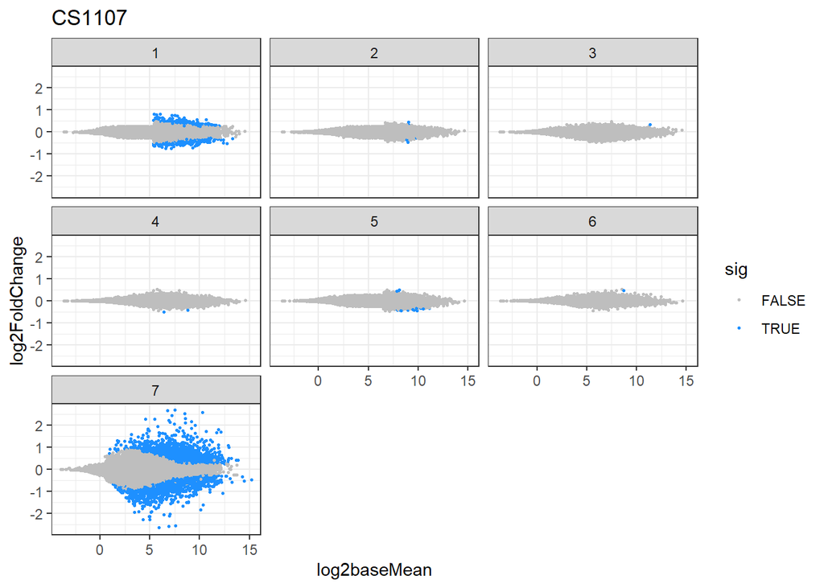

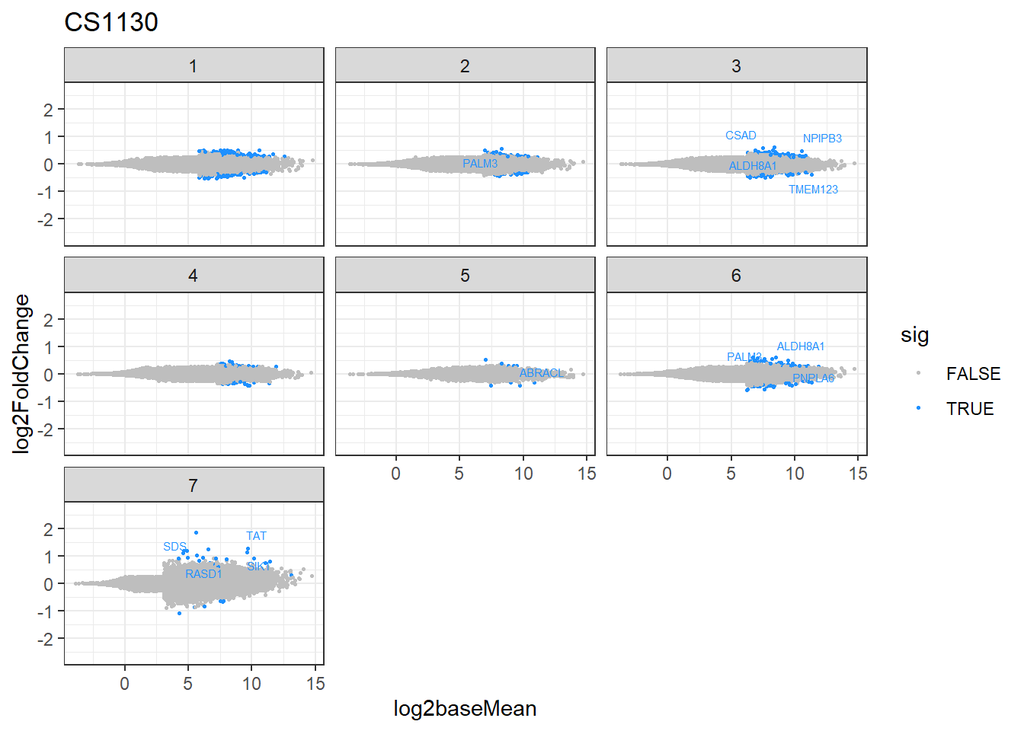

```r
#
for(i in unique(metaData$compound_ID)[1:2]) {
  print(res %>%
          separate(mean_ID, sep="_", into=c("Compound", "Conc_ID", NA), remove=F) %>%
          filter(!is.na(sig) & Compound == i) %>%
          mutate(log2baseMean = log2(baseMean)) %>%
          ggplot(aes(x = log2baseMean, y = log2FoldChange)) +
          geom_point(aes(color=sig), size=0.5) +
          geom_text_repel(aes(label = ifelse(padj < 1E-4, gene_symbol, NA)),
                    color="dodgerblue", size=2) +
          ylim(-max(abs(res$log2FoldChange), na.rm=T), max(abs(res$log2FoldChange), na.rm=T)) +
          scale_color_manual(values = c("grey", "dodgerblue")) +
          theme_bw() +
          ggtitle(i) +
          facet_wrap(~Conc_ID))
}
```

Metformin: - The lowest concentration shows a few DEGs with a significant biological response - The concentrations 2-6 show almost no DEGs that indicate a significant biological response - The highest concentration shows a large number of DEGs that have a significant biological response

Theophylline: - There are not many DEGs that show a strong biological responses across all the concentrations

# 5 Advanced question

## 5.1 Gene level plots

It can also be useful to plot individual gene results, especially to investigate gene-level dose responses.

**Exercise 21: Plot the top 16 genes for each of the compounds in a dose-response plot. Are there any genes with particular relevance to hepatotoxicity?**

```r
# Get the top 16 unique gene symbols from the res_high data frame, sorted by the lowest adjusted p-values (padj), indicating the most statistically significant genes in a high-expression condition
top_high <- unique((res_high %>% arrange(padj))$gene_symbol)[1:16]
top_high
```

```
##  [1] "TAT"     "SDS"     "ALDH8A1" "RASD1"   "ABRACL"  "SIK1"    "TMEM123"
##  [8] "NPIPB3"  "PNPLA6"  "PALM3"   "CSAD"    "EID3"    "TRIB3"   "ATP5PF"
## [15] "MRTFA"   "VDAC2"
```

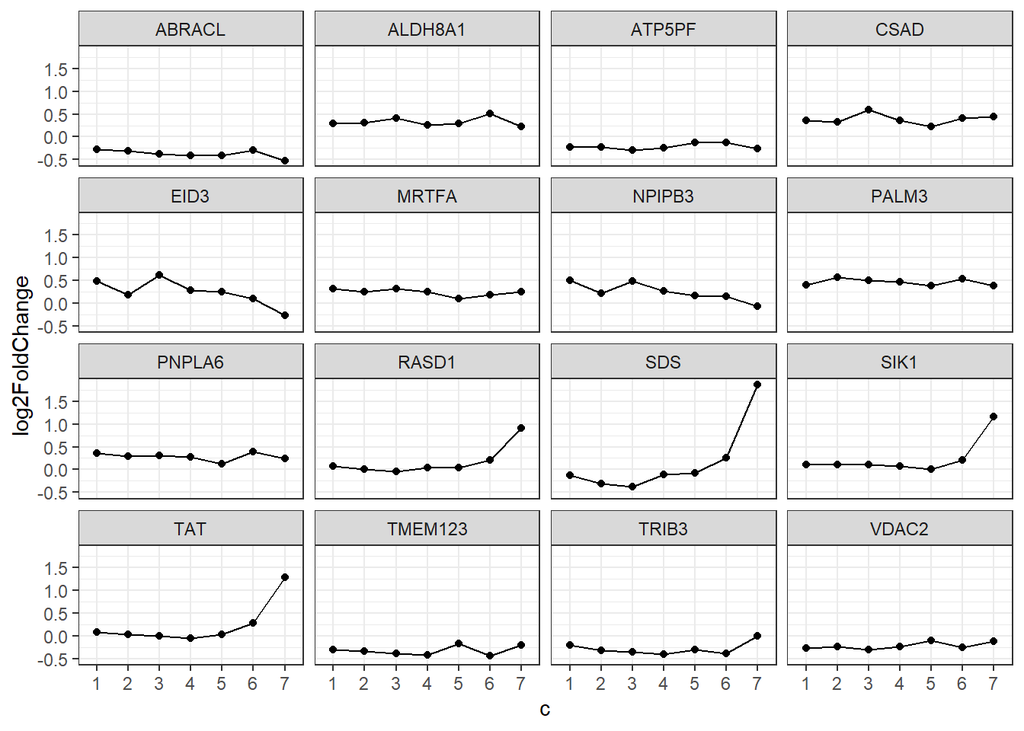

```r
res_high %>%
  filter(gene_symbol %in% top_high) %>%
  separate(mean_ID, sep="_", into=c('comp', 'c', NA), remove=F) %>%
  ggplot(aes(x=c, y=log2FoldChange)) +
  geom_point() +
  geom_line(aes(group=gene_symbol)) +
  facet_wrap(~gene_symbol) +
  theme_bw()
```

Theophylline Genes involved in: - The metabolic functions of the liver, with an emphasis on amino acid metabolism, energy production, and lipid homeostasis. - Regulating stress through circadian regulation and stress response. - Maintaining cell structure and membrane integrity - Regulating detoxification

```r
# Get the top 16 unique gene symbols from the res_low data frame, sorted by the lowest adjusted p-values (padj), indicating the most statistically significant genes in a high-expression condition
top_low <- unique((res_low %>% arrange(padj))$gene_symbol)[1:16]
top_low
```

```
##  [1] "PALLD"   "KRT7"    "MSMO1"   "FGF2"    "RTP3"    "INHBE"   "TGFB2"
##  [8] "VIL1"    "INSIG1"  "ANXA3"   "S100A14" "CTNND1"  "FLNB"    "PLK2"
## [15] "HMGCS1"  "NME1"
```

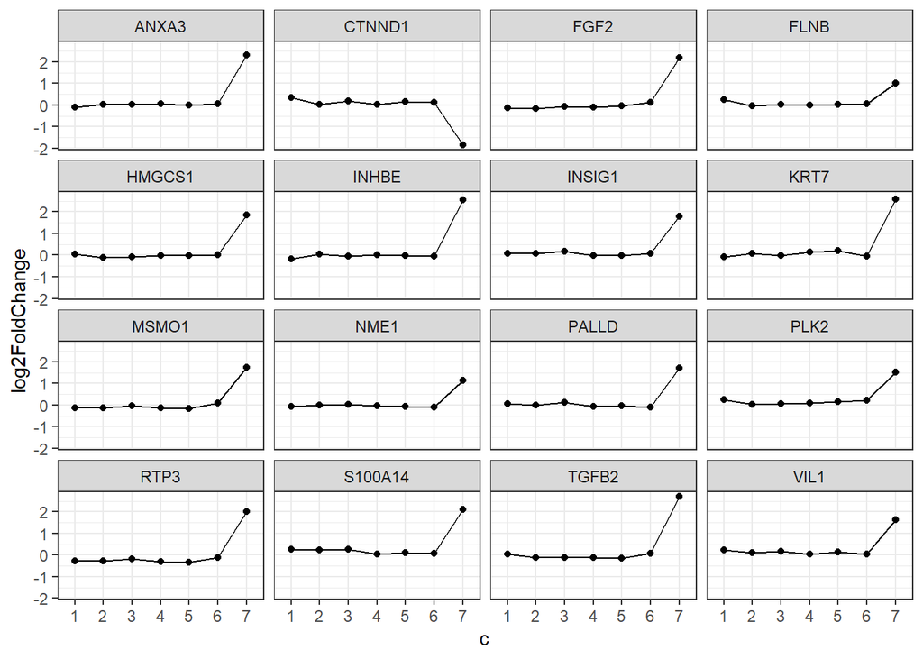

```r
res_low %>%
  filter(gene_symbol %in% top_low) %>%
  separate(mean_ID, sep="_", into=c('comp', 'c', NA), remove=F) %>%
  ggplot(aes(x=c, y=log2FoldChange)) +
  geom_point() +
  geom_line(aes(group=gene_symbol)) +
  facet_wrap(~gene_symbol) +
  theme_bw()
```

Metformin Genes involved in: - Maintaining the structure and stability of epithelial cells - Actin cytoskeleton regulation - Cholesterol biosynthesis - Cell adhesion

```r
# Get the first 16 unique gene symbols (with the smallest adjusted p-values) from sample "CS1107_1_P2" in the res_low dataset.
bottom_low <- res_low %>%
  filter(mean_ID == "CS1107_1_P2") %>%
  arrange(padj) %>%
  pull(gene_symbol) %>%
  unique() %>%
  head(16)
bottom_low
```

```
##  [1] "PHRF1"   "NPIPB3"  "TXNDC17" "ATP5MG"  "ESD"     "RBP4"    "STOM"
##  [8] "RPS29"   "S100A10" "EID3"    "NDUFV2"  "ECHS1"   "NPIPA5"  "YWHAE"
## [15] "GSDMB"   "IL18BP"
```